# Epidemic Spreading: SIS Model & SIR Model

Letitia Kernschmidt

# 1 Example Network: Dolphins

The example network is a social network of bottlenose dolphins. The nodes are the bottlenose dolphins (genus Tursiops) of a bottlenose dolphin community living off Doubtful Sound, a fjord in New Zealand (spelled fiord in New Zealand). An edge indicates a frequent association. The dolphins were observed between 1994 and 2001.

- Type: Undirected, unweighted
- Vertices (Dolphins): 62
- Edges (Associations): 159
- Category: Animal

*Source*: http://konect.uni-koblenz.de/networks/dolphins

Note that this network was selected, because it has such a small size that it can be easily plotted for visualization purposes.

**Epidemic Parameters**  
For visualization purposes, both the infection rate as well as the recovery rate are set quite high. For real life epidemic spreading simulations, these rates have to be adjusted accordingly.

# 2 SIS Model

For diseases that do not confer immunity against reinfection (e.g. most bacterial diseases), the SIS-Model was introduced. Similar to the SI-Model, there are only two classes, namely the susceptible and the infected class. In this case, however, individuals can move back and forth between the infected class and the susceptible class, i.e. recover from the infection and get reinfected.

### 2.0.1 Preparation

Before starting with the analysis, RStudio and ImageMagick need to be installed.  
**IMPORTANT**: When installing ImageMagick, the option “Install legacy components (convert.exe etc)” MUST be selected.

- **RStudio** can be downloaded here: https://www.rstudio.com/products/rstudio/download3/
- **ImageMagick** can be downloaded here: http://www.imagemagick.org/script/binary-releases.php

### 2.0.2 Loading the Network Dataset

```r
# Load the igraph, the animation, and the xtable package (needs to be installed in R before use)
library(igraph)
library(animation)
library(xtable)

# Set your working directory - this is especially important if you want to save the animation
# setwd("INSERT HERE YOUR WORKING DIRECTORY")
```

```r
# Load a network from a .csv file
dat=read.csv(file.choose(),header=TRUE)
el=as.matrix(dat)
el[,1]=as.character(el[,1])
el[,2]=as.character(el[,2])
n=graph.edgelist(el,directed=FALSE)
```

```r
# Set N as the number of individuals, i.e. vertices in the network
N = vcount(n)

# Set init_inf as the number of initially infected individuals
init_inf = 1

# Set simlength as the number of time steps - might need to be adjusted after first trial
# Therefore, see, e.g., the prevalence table created below to get a better overview
simlength = 30

# Set simnumber as the number of simulations
simnumber = 1

# Set beta as the infection rate
beta = 0.5

# Set gamma as the recovery rate
gamma = 0.4

# Switch to set whether you would like to plot the spreading of the epidemic over the network
# Caution: might significantly slow down the simulation when TRUE
plot.spread = TRUE

# Generate an edge list from the loaded network dataset.
# Caution: "names" MUST be set as FALSE!
# >> Otherwise, the vertex names are saved as strings, which will lead to an error
links = as_edgelist(n, names = FALSE)

# infdata_sum is a list, which will be used to save the list of infection data of each simulation round
infdata_sum = list()
# susdata_sum is a list, which will be used to save the list of susceptible data of each simulation round
susdata_sum = list()
# incidence_sum is a list, which will be used to save the list of the incidence data of each simulation round
incidence_sum = list()
```

### 2.0.3 Simulation

```r
# The for loop is used to run the simulation as often as defined in simnumber
for (j in 1:simnumber){

# Initialization of the infection status - at the beginning all individuals are susceptible
infected = logical(N)

# Selecting the "patient zero". In this case the first infected individuals are picked randomly
# Example: If one would like to manually select the initially infected individual (vertex 5),
# one can select:
# patientzero = 5
patientzero = sample(N,init_inf)

# The initially selected infected individuals are now set to be infected
infected[patientzero] = TRUE

# The number of susceptibles is hence the total number of individuals N - the number of infected individuals
# The number of infected individuals is found by sum(infected)
susceptible = N - sum(infected)

# infdata is a list, which is used to save the infection data of each timestep within one simulation round
# As described above the whole list of each simulation round is saved in infdata_sum
# (i.e. infdata_sum is a nested list)
infdata = list(sum(infected))

# susdata is a list, which is used to save the susceptible data of each timestep within one simulation round
# As described above the whole list of each simulation round is saved in susdata_sum
# (i.e. susdata_sum is a nested list)
susdata = list(susceptible)

# The incidence is the average number of new cases per day caused by all infectives.
# At timestep 0 the list is empty
incidence = list()

########################################################################################################

# Here the parameters for the animated simulation are set
if (plot.spread) {
  # Remember to adjust this, if the graph is directed
    network.i = graph.edgelist(links, directed=FALSE)
    # Store a fixed layout for the graph
    fixlayout = layout.kamada.kawai(network.i)
    # Initialize the vertex colors (SkyBlue2 is also the default node colour in igraph)
    # As a first step all vertices are colored blue
    node.colour = rep("SkyBlue2",N)
    # Infected vertices will be coloured red
  node.colour[patientzero] = "red"
  # In order to save the network at timestep 0, it must be saved in this step, otherwise this step will
  # be missing in the simulation
  # The filename of this plot will be sim.000. This is important as described below!
  png(paste("sim", 000, ".png", sep = "."))
  # Now the network is plotted. The heading of the plot shows the respective timestep
    plot(network.i,layout=fixlayout, main="Time = 0", vertex.color=node.colour)
    # It is important to set dev.off after saving the image, because it will otherwise not be accessible
    dev.off()
}

########################################################################################################

# As described above it is important to save the first plot as *000.
# This is, because the .png files of each timestep are later on set together to a single .gif file
# During the simulation, the filenames are created on the fly
# (in this way they are automatically adjusted if the number of timesteps is changed).
# If they are saved without leading zeros, i.e. without padding, the convert function of ImageMagick
# will sort the files as 1,10,11,2,3,...
# In order to achieve the correct sorting, the filenames must be padded > 000, 001,002,003,...010,011,...
# Therefore, the following function is used
pad_int = function(n,scale){
  out_string = paste(10*scale + n,sep='')
  out_string = substr(out_string,2,nchar(out_string))
  return(out_string)
}

########################################################################################################

# Here the actual simulation starts
for (i in 1:simlength) {

  # If there is at least one infected vertex in the network,
  # all infected vertices can recover
  if (sum(infected) > 1){
    # Select all vertices, which are currently infected
    infected.vertices = which(infected)
    # Determine randomly which of the infected vertices will recover during this timestep
    recover = rbinom(sum(infected),1,gamma)
    # Those vertices for which the rbinom function returns 1 are selected to recover during this timestep
    recover.vertices = infected.vertices[recover==1]
    # The selected vertices are set to FALSE in the infected logical vector
    infected[recover.vertices] = FALSE
  }


  # Find the indeces of edges that connect an infected individual to an uninfected
  discordant.links = which(xor(infected[links[,1]],infected[links[,2]]))
  # Determine randomly which of the discordant edges transmits the disease
  transmit = rbinom(length(discordant.links),1,beta)
  # The infection vector is updated
  transmitter.links = discordant.links[transmit==1]
  # Gets both vertices of the transmitter links into a single vector; unique just filters out repetitions
  nodes.of.transmitter.links = unique(as.vector(links[transmitter.links,1:2]))
  # Both vertices are set to TRUE (although the transmitter already had 'TRUE').
  # In more complex models, you might want to overwrite only the newly infected vertices.
  infected[nodes.of.transmitter.links] = TRUE
  # As mentioned above the infdata list is used to save the number of infected individuals at each timestep
  # In order to save also the initial number, i.e. init_inf = 2, the current number must be saved at i+1
  infdata[[i+1]] = sum(infected)
  # The same explanation as with infdata applies also for susdata
  susdata[[i+1]] = N - sum(infected)
  # The incidence is calculated as the number of susceptibles at timestep i minus the number or susceptibles
  # at timestep i+1
  incidence[[i]] = susdata[[i]] - susdata[[i+1]]
  # If the animation is desired the following steps will be executed
  if (plot.spread) {
    # In order to ensure that the recovered vertices are marked as susceptible again,
    # all vertices are initially set to blue
    node.colour = rep("SkyBlue2",N)
    # Each infected vertex will then be colored in red
    node.colour[infected] = "red"
    # Here the padding of the filename is adjusted.
    # In this case, we have a padding of 3 digits (>100), meaning 001,002,...010,...
    # If more than 100 files are ment to be saved, the padding would have to be adjusted accordingly to 1000
    padded = pad_int(i,100)
    # The filename is created on the fly and padded - each filename contains the timestep i
    png(paste("sim",padded,".png", sep=""))
    # The acutal plotting of the network at each timestep
    plot(network.i,layout = fixlayout, main=paste("Time =", i), vertex.color=node.colour)
  }
  # As described above, dev.off() after creating the .png files is required
  # CAUTION!: If you set plot.spread to FALSE, you must either delete dev.off() or set it into comments
  dev.off()
}
# After the simulation is completed, the whole infdata list is saved within infdata_sum (nested list)
  infdata_sum[[j]] = infdata
# After the simulation is completed, the whole susdata list is saved within susdata_sum (nested list)
  susdata_sum[[j]] = susdata
# After the simulation is completed, the whole incidence list is saved within incidence_sum (nested list)
  incidence_sum[[j]] = incidence
}
```

### 2.0.4 Animation and Analysis

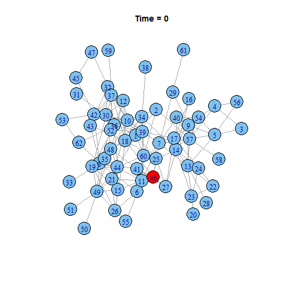

```r
# Here the files of each timestep are set together to one .gif file
# This is done by using the ImageMagick convert function
# CAUTION!!: This is acutally a system command and is hence executed by using the shell function
# This is, however, platform dependent, meaning that this line must be adjusted according to the used OS
# The shell funtion is applicable for WINDOWS
shell("convert -delay 100 *.png Simulation.gif")
```

#### 2.0.4.1 Prevalence

The prevalence is the number of cases of a disease at a given time.

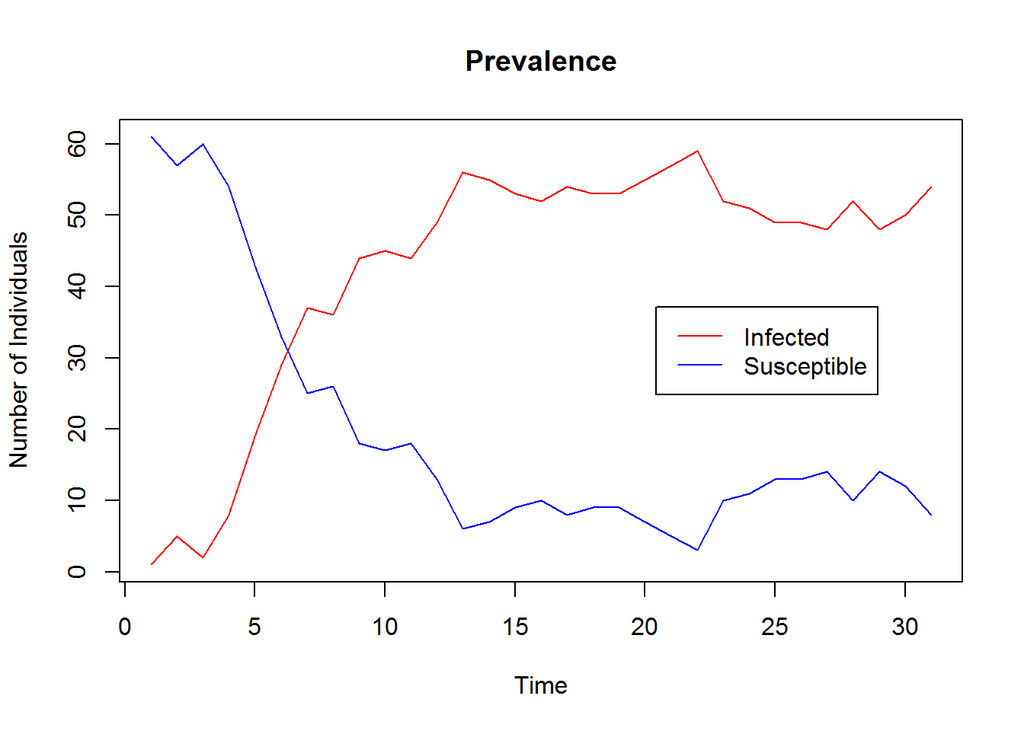

```r
######################################### PREVALENCE #########################################

# The prevalence is the number of cases of a disease at a given time

# As described above, infdata_sum is a NESTED list (a list of lists).
# In order to analyse this data, it must be first converted to a dataframe
# Thereby, the rownames and columnnames are adjusted accordingly
infdata_table = as.data.frame(do.call(rbind,infdata_sum))
colnames(infdata_table) = paste("Time", 0:simlength)
rownames(infdata_table) = paste("Sim", 1:simnumber)

# In order to get a better overview over the data, an html table is created
# The output file can be found in the working directory
# Alternatively xtable could be also used to directly create a Latex table
# NOTE: If this code is run as R File in Rstudio, it might be sufficient to just run
# view(infdata_table)
# This will open a new tab displaying a nicely formatted table, which is, however, NOT savable
# In case only the view option is selected, the xtable library is not required
infdata_table = xtable(infdata_table, digits = 0, caption="Prevalence")
print(infdata_table, type="html", file="PrevalenceTableGnutella.html")

# In order to plot all simulation results in one single plot, the dataframe must be converted to a matrix
infdata_table = as.matrix(infdata_table)

# The same procedure must be then repeated for the susdata_sum list
susdata_table = as.data.frame(do.call(rbind,susdata_sum))
colnames(infdata_table) = paste("Time", 0:simlength)
rownames(infdata_table) = paste("Sim", 1:simnumber)
susdata_table = as.matrix(susdata_table)

# In order to plot both results, i.e. the susceptible data AND the infected data into one plot,
# both matrices are combined to one matrix
combined = rbind(infdata_table, susdata_table)

# In order to plot all simulation results within one plot, matplot is used
# Thereby, one needs to specify the type of plot, which in this case is line >> type="l"
# In order to color the susceptible data in blue and the infected data in red, the ifelse condition is set.
# All data rows that start with a number higher than the initially infected individuals will be colored blue
matplot(t(combined), type="l", lty = 1, col = ifelse(combined[,c("Time 0")] > init_inf, "blue", "red"), xlab = "Time", ylab = "Number of Individuals")
title(main = "Prevalence")
legend("right", inset = .10, legend=c("Infected", "Susceptible"), col=c("red","blue"), lty = 1:1)
```

#### 2.0.4.2 Incidence

The incidence is the number of new infections per time step.

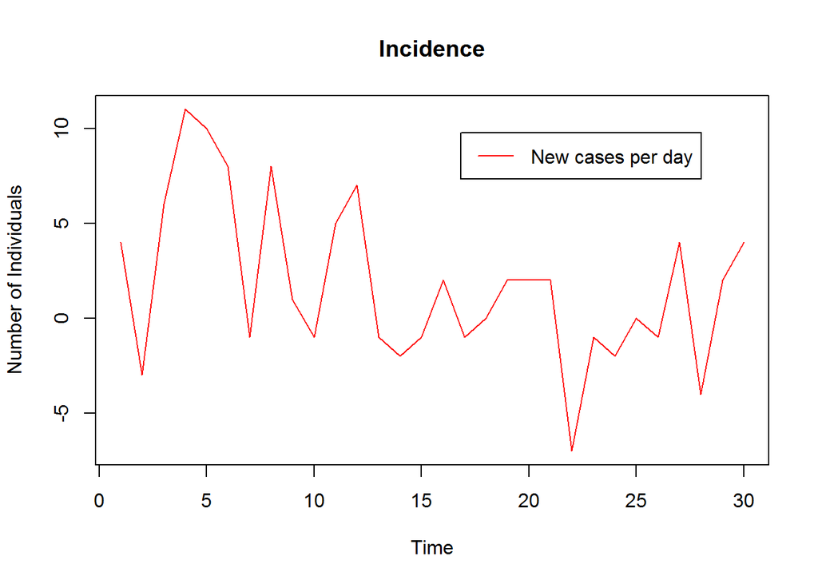

```r
######################################### INCIDENCE #########################################

# As described above, also the incidence data must be first converted to a data frame
incidence_table = as.data.frame(do.call(rbind,incidence_sum))
colnames(incidence_table) = paste("Time", 1:simlength)
rownames(incidence_table) = paste("Sim", 1:simnumber)

# In order to get a better overview over the data, an html table is created
# The output file can be found in the working directory
# Alternatively xtable could be also used to directly create a Latex table
incidence_table = xtable(incidence_table, digits = 0, caption="Incidence")
print(incidence_table, type="html", file="IncidenceTableGnutella.html")

# Convert the incidence table to a matrix for plotting
incidence_table = as.matrix(incidence_table)

# Plot all results within one plot including a legend
matplot(t(incidence_table), type="l", lty = 1, col = "red", xlab = "Time", ylab = "Number of Individuals")
title(main = "Incidence")
legend("topright", inset = .10, legend=c("New cases per day"), col=c("red"), lty = 1)
```

# 3 SIR Model

The SIR-Model (Susceptible-Infected-Recovered Model) is an extension of the SI-Model and is used to model infections from which infected individuals recover with immunity (e.g. most diseases transmitted by viral parasites). It consists of the three classes susceptible, infected and recovered. Whereas the susceptible and the infected classes are equal to the ones of the SI-Model, individuals in the recovered class have recovered from the disease with immunity and cannot transmit the disease to any other individual. Infected individuals are assumed to recover (or die) from the disease at a constant average recovery rate gamma. Hence, the average duration of infection is equal to 1/gamma.

Note that only those parts that include code that differs from the SIS Model is displayed. Furthermore, only the required changes are commented. For comments on the other lines of code please see the SIS Model.

```r
N = vcount(n)
init_inf = 1
simlength = 30
simnumber = 1
beta = 0.5
gamma = 0.14
plot.spread = TRUE

# Set to FALSE if the vertices cannot recover from timestep 0 to timestep 1
recovery.wait = FALSE

links = as_edgelist(n, names = FALSE)
infdata_sum = list()
susdata_sum = list()

# recdata_sum is a list, which will be used to save the list of the recovery data of each simulation round
recdata_sum = list()

incidence_sum = list()
```

### 3.0.1 Simulation

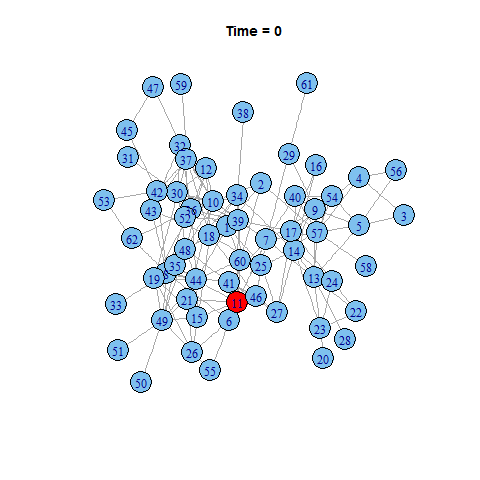

```r
for (j in 1:simnumber){

infected = logical(N)
patientzero = sample(N,init_inf)
infected[patientzero] = TRUE
susceptible = N - sum(infected)

# Recovered vertices are set to NA.
# Hence, rec_na selects those vertices that are set to NA
rec_na = is.na(infected)

# Whereas it is sufficient to use sum(infected) in the SIS model,
# sum(infected==TRUE, na.rm=TRUE) must be used for the SIR model
# This is, because otherwise those vertices, which are set to NA are counted and the result will be wrong
infdata = list(sum(infected==TRUE, na.rm = TRUE))

susdata = list(susceptible)

# recdata is the sum of those vertices, which are set to NA, i.e. recovered with immunity
recdata = list(sum(rec_na))

incidence = list()

########################################################################################################

if (plot.spread) {
    network.i = graph.edgelist(links, directed=FALSE)
    fixlayout = layout.kamada.kawai(network.i)
    node.colour = rep("SkyBlue2",N)
  node.colour[patientzero] = "red"
  png(paste("sim", 000, ".png", sep = "."))
    plot(network.i,layout=fixlayout, main="Time = 0", vertex.color=node.colour)
    dev.off()
}

########################################################################################################

pad_int = function(n,scale){
  out_string = paste(10*scale + n,sep='')
  out_string = substr(out_string,2,nchar(out_string))
  return(out_string)
}

########################################################################################################

for (i in 1:simlength) {

  # Starting from timestep 1 to timestep 2
  if (recovery.wait==FALSE || i > 1){
    infected.vertices = which(infected)
    # Select those vertices which will recover during this timestep using binomial distribution
    # na.rm must be set to TRUE to receive meaningful results
    recover = rbinom(sum(infected==TRUE, na.rm = TRUE),1,gamma)
    recover.vertices = infected.vertices[recover==1]

    # The selected vertices are set to NA in the infected logical vector
    infected[recover.vertices] = NA
  }

  discordant.links = which(xor(infected[links[,1]],infected[links[,2]]))
  transmit = rbinom(length(discordant.links),1,beta)
  transmitter.links = discordant.links[transmit==1]
  nodes.of.transmitter.links = unique(as.vector(links[transmitter.links,1:2]))
  infected[nodes.of.transmitter.links] = TRUE

  # As mentioned above in the SIR model one has to include na.rm = TRUE in order to prevent
  # counting of the NA vertices
  infdata[[i+1]] = sum(infected==TRUE, na.rm = TRUE)
  # As above, na.rm = TRUE has to be included
  susdata[[i+1]] = N - sum(infected==TRUE, na.rm = TRUE) - sum(is.na(infected))
  # The recovery data is the sum of all vertices, which are set to NA
  recdata[[i+1]] = sum(is.na(infected))

  incidence[[i]]=susdata[[i]] - susdata[[i+1]]

  if (plot.spread) {
    node.colour[infected] = "red"

    # Each vertex that has recovered with immunity will be colored in green
    node.colour[recover.vertices] = "green"

    padded = pad_int(i,100)
    png(paste("sim",padded,".png", sep=""))
    plot(network.i,layout=fixlayout, main=paste("Time =", i), vertex.color=node.colour)
  }
  dev.off()
}

infdata_sum[[j]] = infdata
susdata_sum[[j]] = susdata

# After the simulation is completed, the whole recdata list is saved within recdata_sum (nested list)
recdata_sum[[j]] = recdata

incidence_sum[[j]] = incidence
}

shell("convert -delay 100 *.png SimulationSIR.gif")
```

### 3.0.2 Prevalence

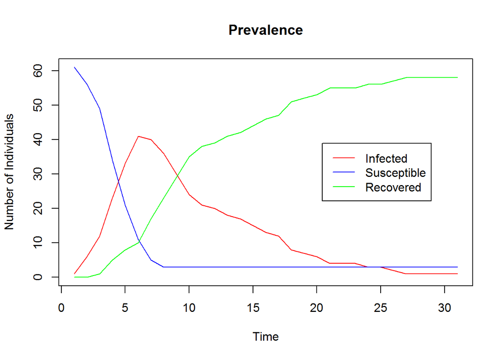

```r
infdata_table = as.data.frame(do.call(rbind,infdata_sum))
colnames(infdata_table) = paste("Time", 0:simlength)
rownames(infdata_table) = paste("Sim", 1:simnumber)
infdata_table = as.matrix(infdata_table)

susdata_table = as.data.frame(do.call(rbind,susdata_sum))
colnames(susdata_table) = paste("Time", 0:simlength)
rownames(susdata_table) = paste("Sim", 1:simnumber)
susdata_table <- as.matrix(susdata_table)

# The same procedure as above must be repeated for the recdata_sum list
recdata_table = as.data.frame(do.call(rbind,recdata_sum))
colnames(recdata_table) = paste("Time", 0:simlength)
rownames(recdata_table) = paste("Sim", 1:simnumber)
recdata_table = as.matrix(recdata_table)

# In order to plot all three results, i.e. the susceptible data AND the infected data AND the recovered data into one plot, all three matrices are combined into one matrix
combined = rbind(infdata_table, susdata_table, recdata_table)

matplot(t(combined), type="l", lty = 1, col = ifelse(combined[,c("Time 0")] == 0, "green", ifelse(combined[,c("Time 0")] > init_inf, "blue", "red")), xlab = "Time", ylab = "Number of Individuals")
title(main = "Prevalence")
legend("right", inset = .10, legend=c("Infected", "Susceptible", "Recovered"), col=c("red","blue", "green"), lty = 1:1)
```

### 3.0.3 Incidence

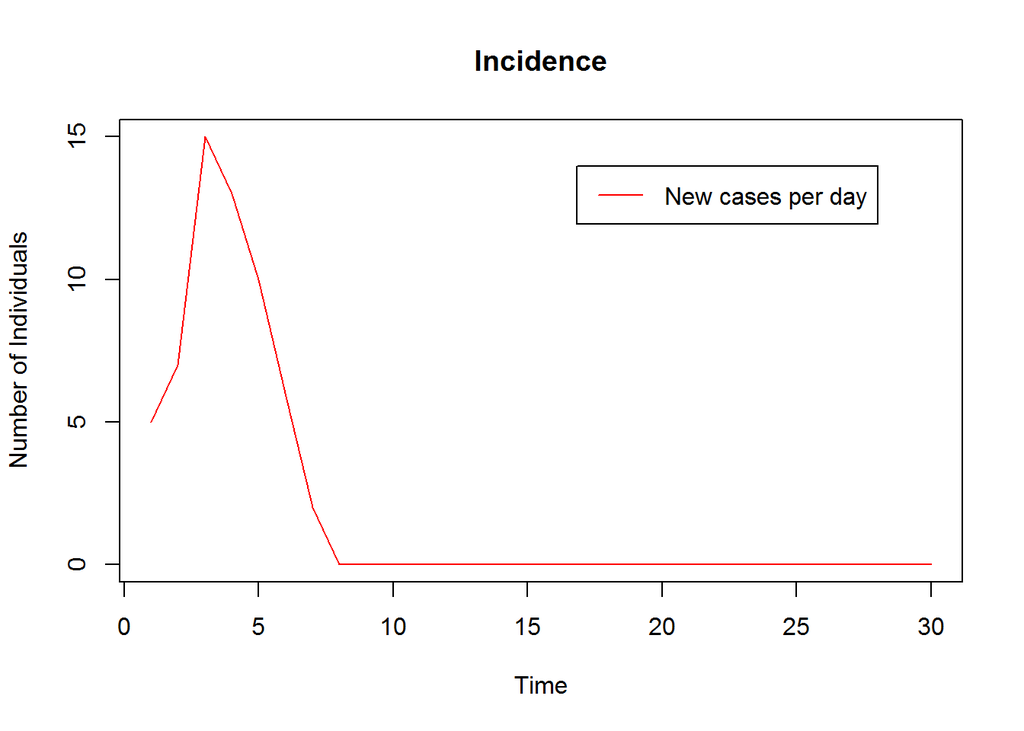

```r
incidence_table = as.data.frame(do.call(rbind,incidence_sum))
colnames(incidence_table) = paste("Time", 1:simlength)
rownames(incidence_table) = paste("Sim", 1:simnumber)

incidence_table = xtable(incidence_table, digits = 0, caption="Incidence")
print(incidence_table, type="html", file="IncidenceTableGnutella.html")

incidence_table = as.matrix(incidence_table)

matplot(t(incidence_table), type="l", lty = 1, col = "red", xlab = "Time", ylab = "Number of Individuals")
title(main = "Incidence")
legend("topright", inset = .10, legend=c("New cases per day"), col=c("red"), lty = 1)
```